# Simulatiestudie effecten gaten in locatiemetingen

Danielle McCool  
13 juli 2021

### Missende data

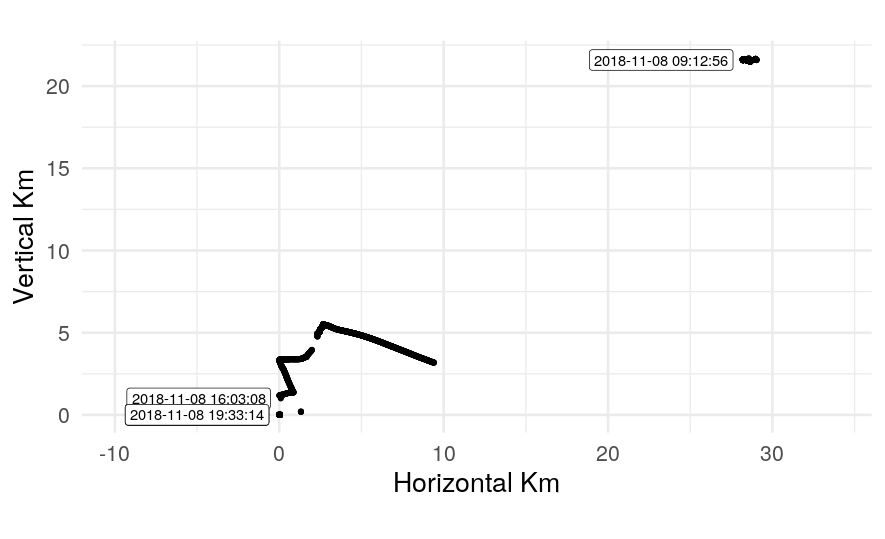

### Missende data - Naive optie 1

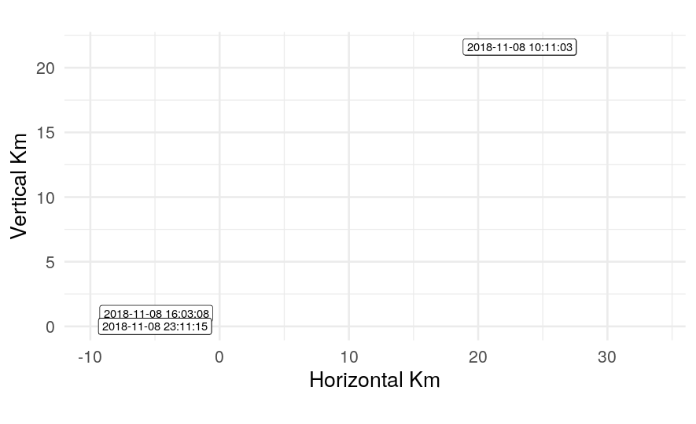

- Uit andere literatuur weten wij dat dit problemen veroorzaakt als diegene met missende data anders zijn
- Verlies aan data

### Missende data - Naive optie 2

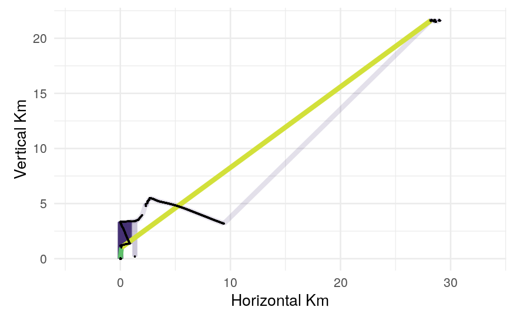

- Pro: Gemakkelijk
- Con: ?

### Geheel data - Defineren

- Tenminste 24 uur
- Geen gat groter dan 5 minuten
- Batterij metingen tellen ook mee

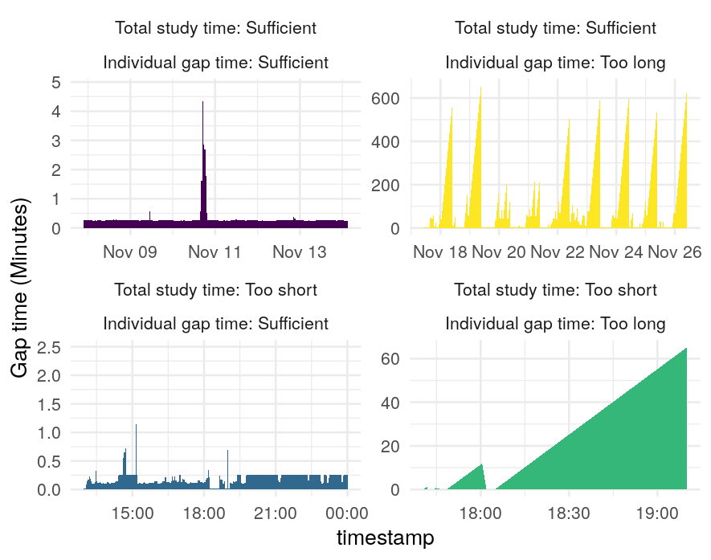

### Geheel data - Vinden

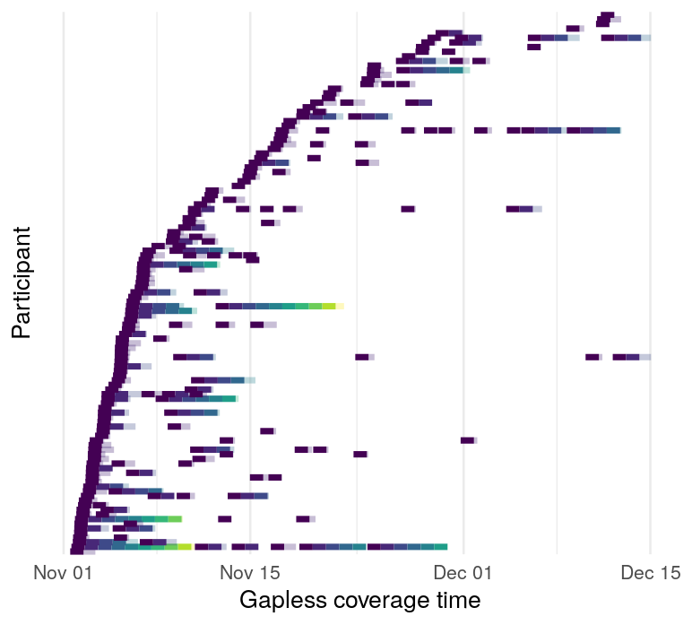

- 117 mensen met tenminste een geheel dag
- ~ 512 hele dagen
- Alle dagen waren opgesplitst in 24u segmenten

### Geheel data - Gevonden

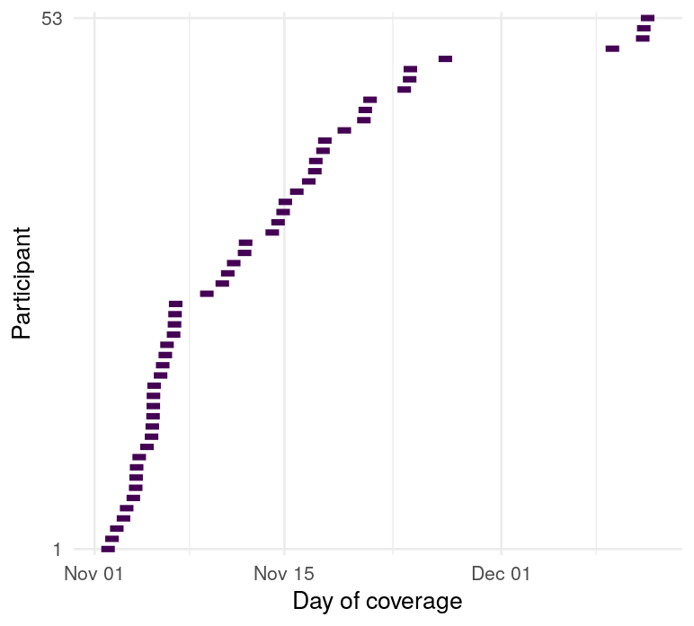

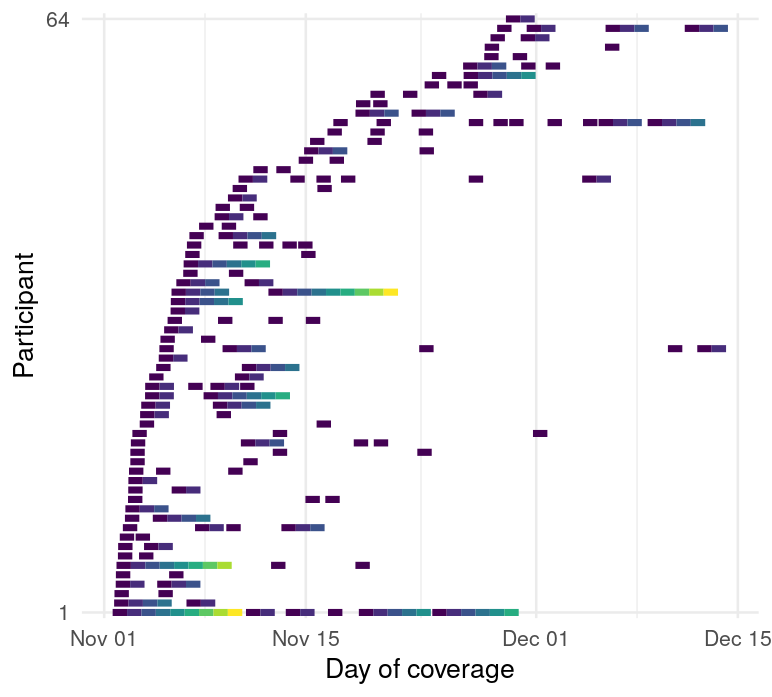

### Geheel data - Multi-dagen

- Deze mensen zijn nuttig voor de toekomst
- Veel mensen hebben meerdere complete dagen maar ook incomplete dagen

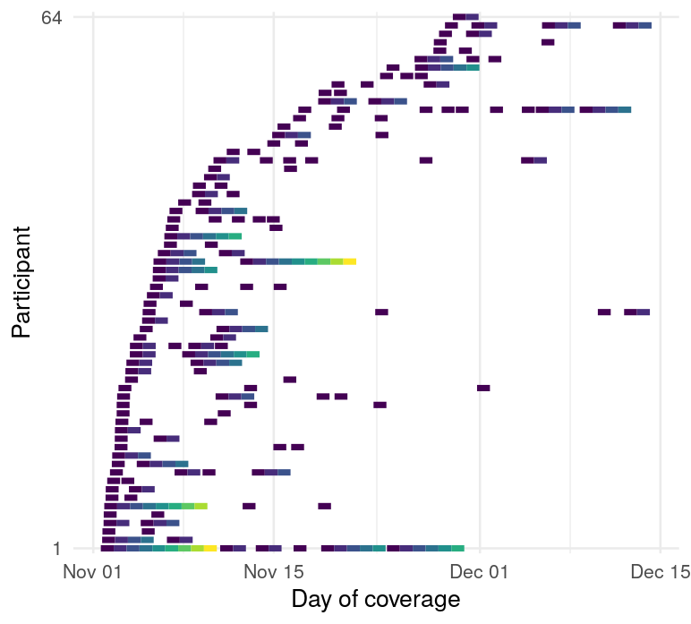

### Segmentatie (Douglas Peucker Algorithme)

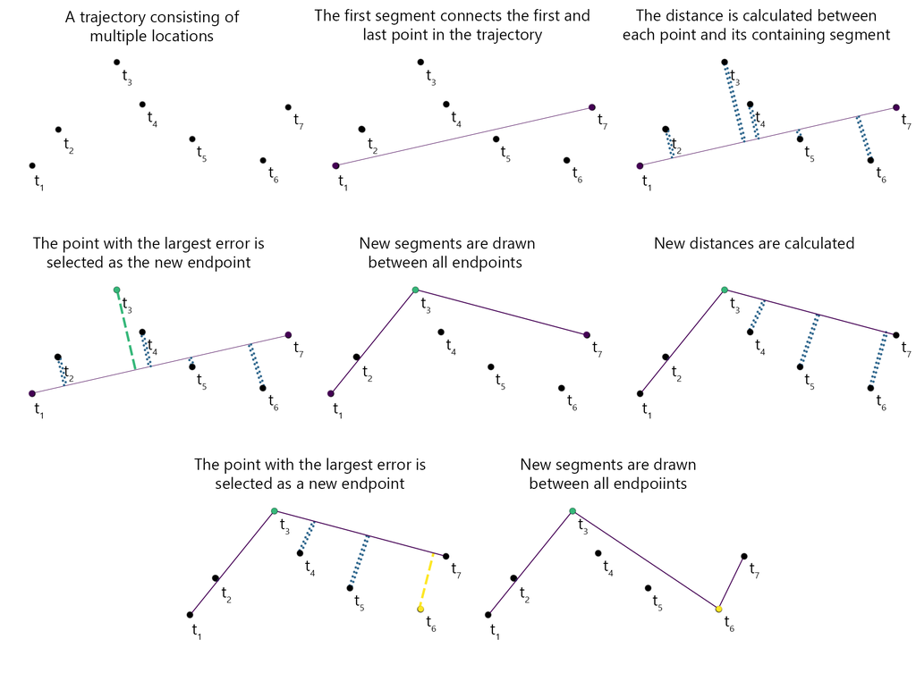

- Eigenlijk gebruikten wij de Top-Down Time Ratio versie hiervan omdat onze data hebben een ongelijk frequentie

### Segmentatie Simulatie

- Juiste error parameter instellen
- Doel is noise uit te filteren maar geen signaal

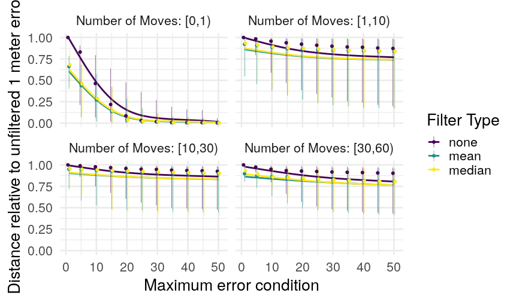

### Drie simulaties

- Short gaps: 5 minuten stukken verwijderen tot een bepaalde sparsity
- Long gaps: Groeiende gap tot een bepaalde sparsity
- Sensitivity analysis: 1 - 20 minuten uit het begin van elk uur gehaald.

### Drie simulaties

- Short gaps: 5 minuten stukken verwijderen tot een bepaalde sparsity
- Long gaps: Groeiende gap tot een bepaalde sparsity
- Sensitivity analysis: 1 - 20 minuten uit het begin van elk uur gehaald.

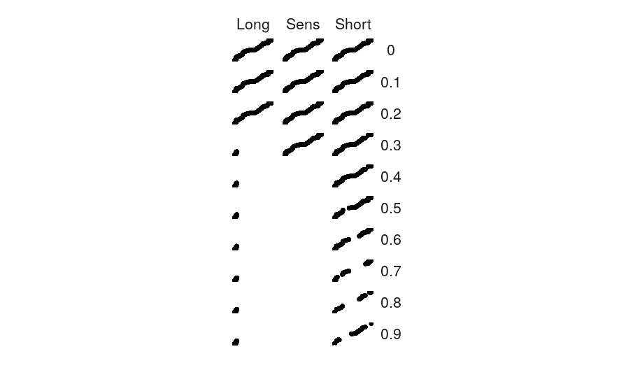

### Drie simulaties - Dichtbij

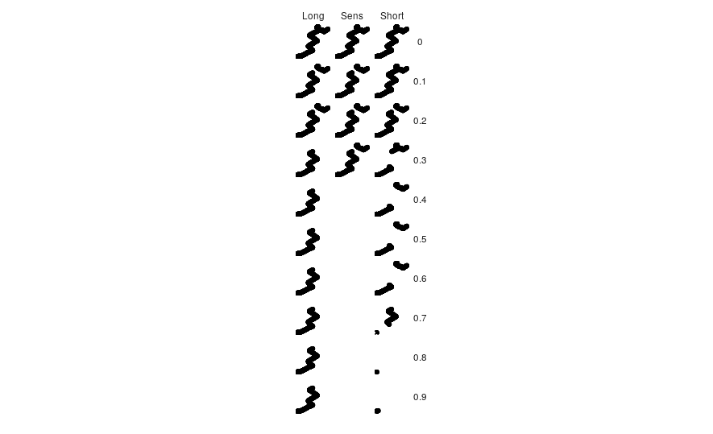

### Short gaps

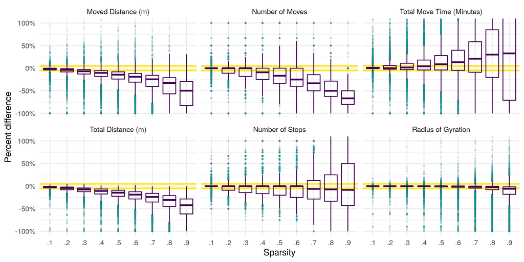

### Long gaps

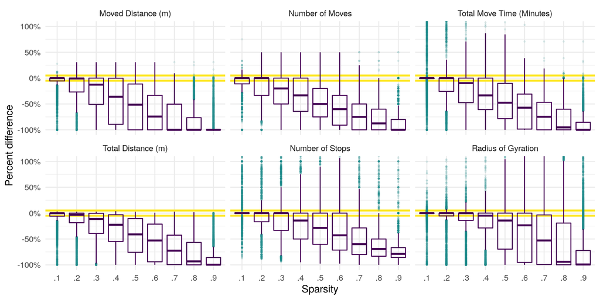

### Comparison

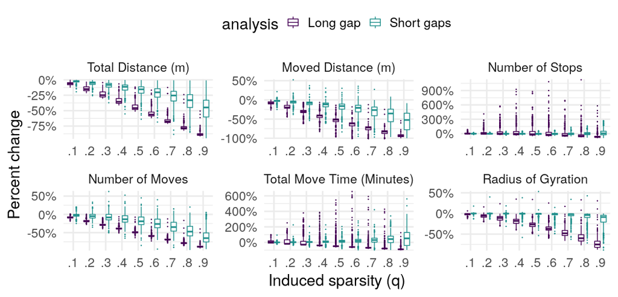

### Sensitivity

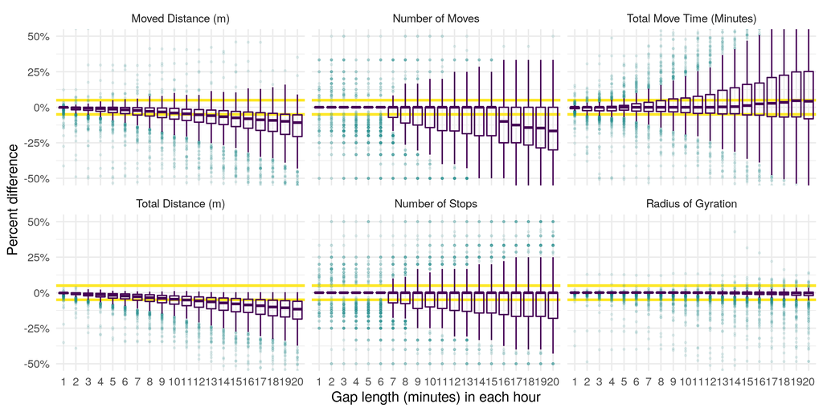